# BSTA504 Midterm Project

Stamatia Vafeas

2023-08-14

# 1. Define the Question

Coffee is American’s most popular beverage. According to Food Beverage Insider, Americans consume more coffee than tap water (https://www.foodbeverageinsider.com/beverages/coffee-consumption-hits-record-high-us). As a graduate student on a budget, I wanted to answer the question, how can I best spend my coffee dollars? The last bag of coffee I bought was a 12 oz bag of Portland Coffee Roasters, Goose Hollow coffee beans for $11.99 at Safeway. While this exact blend was not listed on Coffee Review’s website, other blends of Portland Coffee Roasters (previously called Portland Roasters, https://www.portlandcoffeeroasters.com/consumer/learn/about-us/mission-history) are listed. For this analysis, I will using the Mocha Java blend, which was rated at 89, as a substitute for Goose Hollow.

In order to answer this question, I used the data from Coffee Review’s website (https://www.coffeereview.com/). This website was started in 1997 by two people who were determined to provide a wine style rating to coffee. The data used for this analysis was sourced from (https://www.kaggle.com/datasets/hanifalirsyad/coffee-scrap-coffeereview/versions/2?resource=download&select=coffee_fix.csv) and the file used was coffee_fix.csv. The dataset in question includes multiple currencies and unit of measure. In order to streamline my analysis, I filtered the dataset to included only coffees whose prices were listed in USD.

# 2. Import Data

Prior to importing the data, I looked at the excel sheet to check that there were not any missing lines that needed to be addressed during the import. There were not so I was able to improve the data using a basic read.csv() command.

```r
# coffee budget
budget_per_bag <- 11.99 #cost of 12oz of Portland roasters from Safeway

coffee_data <- read.csv(here("data", "coffee_fix.csv"), na = "NA")
glimpse(coffee_data)
```

```
## Rows: 2,282
## Columns: 20
## $ slug        <chr> "https://www.coffeereview.com/review/sweety-espresso-blend…
## $ all_text    <chr> " \n\n\n95\n\n\nA.R.C.\n“Sweety” Espresso Blend\n\n\n\n\n\…
## $ rating      <int> 95, 94, 92, 92, 94, 93, 93, 93, 93, 94, 95, 93, 92, 90, 90…
## $ roaster     <chr> "A.R.C.", "A.R.C.", "Revel Coffee", "Roast House", "Big Cr…
## $ name        <chr> "“Sweety” Espresso Blend", "Flora Blend Espresso", "Ethiop…
## $ location    <chr> "Hong Kong, China", "Hong Kong, China", "Billings, Montana…
## $ origin      <chr> "Panama; Ethiopia", "Africa; Asia Pacific", "Guji Zone, so…
## $ roast       <chr> "Medium-Light", "Medium-Light", "Medium-Light", "Medium-Li…
## $ est_price   <chr> "HKD $250/227 grams", "HKD $158/227 grams", "$16.00/12 oun…
## $ review_date <chr> "November 2017", "November 2017", "November 2017", "Novemb…
## $ agtron      <chr> "50/73", "54/77", "54/70", "53/79", "48/70", "66/92", "54/…
## $ aroma       <int> 9, 9, 9, 8, 9, 9, 9, 9, 9, 9, 9, 9, 9, 8, 8, 8, 7, 8, 9, 8…
## $ acid        <int> NA, NA, 8, 8, 9, 8, 8, 8, 9, 9, 9, 8, NA, 8, NA, NA, NA, 8…
## $ body        <int> 9, 9, 8, 9, 9, 9, 9, 9, 8, 9, 9, 9, 8, 7, 8, 8, 8, 9, 8, 9…
## $ flavor      <int> 9, 9, 9, 9, 9, 9, 9, 9, 9, 9, 9, 9, 8, 9, 9, 8, 8, 9, 9, 8…
## $ aftertaste  <int> 9, 8, 8, 8, 8, 8, 8, 8, 8, 8, 9, 8, 8, 8, 7, 8, 7, 8, 8, 7…
## $ with_milk   <int> 9, 9, NA, NA, NA, NA, NA, NA, NA, NA, NA, NA, 9, NA, 8, 7,…
## $ desc_1      <chr> "Evaluated as espresso. Sweet-toned, deeply rich, chocolat…
## $ desc_2      <chr> "An espresso blend comprised of coffees from Panama and Et…
## $ desc_3      <chr> "A radiant espresso blend that shines equally in the strai…
```

# 3. Overview of ratings

In order to visualize the range of ratings within this dataset, I split up the ratings into smaller ranges. Using glimpse() below, you can see that the dataset was successful split into the different rating ranges.

```r
coffee_data <- coffee_data %>%
  mutate(
    rating_ranges = case_when(
      rating < 80 ~ "<80",
      rating >= 80 & rating < 85 ~ "80-84",
      rating >= 85 & rating < 90 ~ "85-89",
      rating >= 90 & rating < 95 ~ "90-94",
      rating >= 95 ~"95 and up"
    )
  )
glimpse(coffee_data)
```

```
## Rows: 2,282
## Columns: 21
## $ slug          <chr> "https://www.coffeereview.com/review/sweety-espresso-ble…
## $ all_text      <chr> " \n\n\n95\n\n\nA.R.C.\n“Sweety” Espresso Blend\n\n\n\n\…
## $ rating        <int> 95, 94, 92, 92, 94, 93, 93, 93, 93, 94, 95, 93, 92, 90, …
## $ roaster       <chr> "A.R.C.", "A.R.C.", "Revel Coffee", "Roast House", "Big …
## $ name          <chr> "“Sweety” Espresso Blend", "Flora Blend Espresso", "Ethi…
## $ location      <chr> "Hong Kong, China", "Hong Kong, China", "Billings, Monta…
## $ origin        <chr> "Panama; Ethiopia", "Africa; Asia Pacific", "Guji Zone, …
## $ roast         <chr> "Medium-Light", "Medium-Light", "Medium-Light", "Medium-…
## $ est_price     <chr> "HKD $250/227 grams", "HKD $158/227 grams", "$16.00/12 o…
## $ review_date   <chr> "November 2017", "November 2017", "November 2017", "Nove…
## $ agtron        <chr> "50/73", "54/77", "54/70", "53/79", "48/70", "66/92", "5…
## $ aroma         <int> 9, 9, 9, 8, 9, 9, 9, 9, 9, 9, 9, 9, 9, 8, 8, 8, 7, 8, 9,…
## $ acid          <int> NA, NA, 8, 8, 9, 8, 8, 8, 9, 9, 9, 8, NA, 8, NA, NA, NA,…
## $ body          <int> 9, 9, 8, 9, 9, 9, 9, 9, 8, 9, 9, 9, 8, 7, 8, 8, 8, 9, 8,…
## $ flavor        <int> 9, 9, 9, 9, 9, 9, 9, 9, 9, 9, 9, 9, 8, 9, 9, 8, 8, 9, 9,…
## $ aftertaste    <int> 9, 8, 8, 8, 8, 8, 8, 8, 8, 8, 9, 8, 8, 8, 7, 8, 7, 8, 8,…
## $ with_milk     <int> 9, 9, NA, NA, NA, NA, NA, NA, NA, NA, NA, NA, 9, NA, 8, …
## $ desc_1        <chr> "Evaluated as espresso. Sweet-toned, deeply rich, chocol…
## $ desc_2        <chr> "An espresso blend comprised of coffees from Panama and …
## $ desc_3        <chr> "A radiant espresso blend that shines equally in the str…
## $ rating_ranges <chr> "95 and up", "90-94", "90-94", "90-94", "90-94", "90-94"…
```

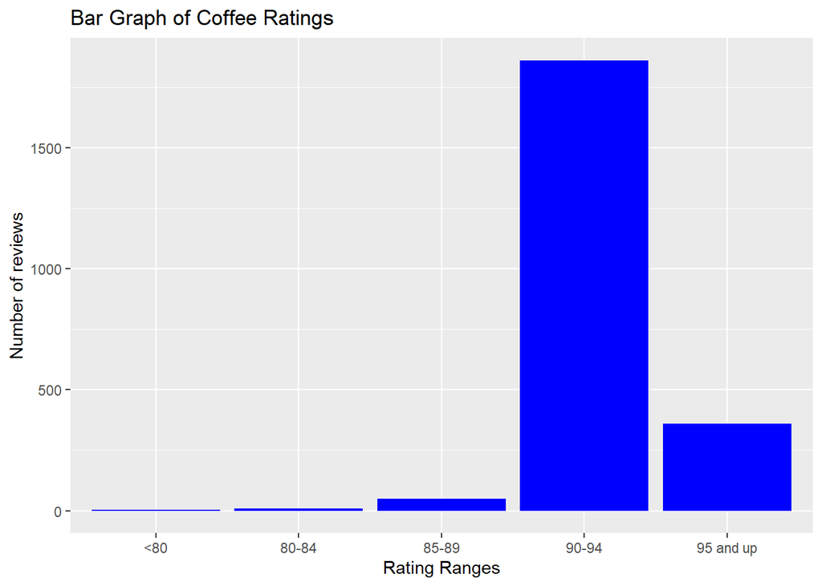

```r
ggplot(coffee_data,
       aes(x = rating_ranges))+
  geom_bar(fill = "blue")+
  labs(x = "Rating Ranges",
       y = "Number of reviews",
       title = "Bar Graph of Coffee Ratings")
```

In the bar graph below, we can see that the large majority of ratings are above Java Mocha’s rating of 89. Using summarize() below, we can see that the range of ratings are from 63 to 98, but the median and mean are both 93 so I am confident that based on this analysis, I’ll be able to find a higher rated coffee for the same price. I also looked at the ratings grouped by roast and for whatever reason, the dark roasts are rated the worst based on median and mean. I am surprised to see that. I had assumed that dark roasts were considered better by coffee snobs experts, but based on the values in the table below, it appears that dark roasts are rated differently than light and medium roasts.

```r
# Range and mean of all coffee ratings
coffee_data %>%
  summarize(minimum_rating = min(rating, na.rm = TRUE),
            maximum_rating = max(rating, na.rm = TRUE),
            mean_rating = round(mean(rating, na.rm = TRUE), digits = 1),
            median_rating = median(rating, na.rm = TRUE))
```

```
##   minimum_rating maximum_rating mean_rating median_rating
## 1             63             98          93            93
```

```r
coffee_data %>%
  group_by(roast) %>%
  summarize(minimum_rating = min(rating, na.rm = TRUE),
            maximum_rating = max(rating, na.rm = TRUE),
            mean_rating = round(mean(rating, na.rm = TRUE), digits = 0),
            median_rating = median(rating, na.rm = TRUE))
```

```
## # A tibble: 7 × 5
##   roast        minimum_rating maximum_rating mean_rating median_rating
##   <chr>                 <int>          <int>       <dbl>         <dbl>
## 1 Dark                     84             94          88            87
## 2 Light                    63             97          93            94
## 3 Medium                   85             97          92            92
## 4 Medium-Dark              83             96          91            92
## 5 Medium-Light             86             98          93            93
## 6 Very Dark                89             89          89            89
## 7 <NA>                     72             96          92            93
```

# 4. Convert all the data within the dataset to cost per 12oz

There are some coffees that are sold in other measurements such as capsules, packets, and pouches. Since those aren’t standardized measures, I’ve removed these values from the dataset. This evaluation will only consider coffee measured in grams or ounces

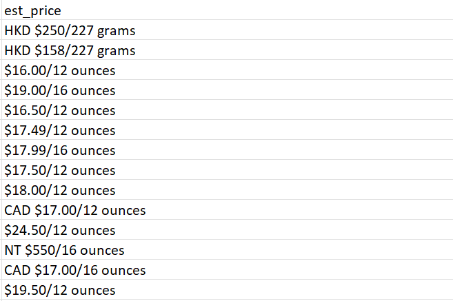

```r
# from my code file

knitr::include_graphics(here("pics", "est_price.png"))
```

Taking the data, we can see that within the “est_price” column, we can fix inconsistencies between the currency and the mass measured for the beans. I am assuming that every column that does not call out a specific currency is using USD so I am splitting the columns up so that we can see the specific currencies evaluated. To simplify my analysis, I decided to filter out all non-US currencies and those coffees which were measured in values other than ounces and grams. I did remove any coffee that had “Cold Brew” in the name. This is because the first time I ran this analysis, I found that the highest rated coffee within my budget was a Cold Brew. Since the volume of a cold brew includes water and coffee, it would be an inaccurate analysis as I’m only looking to evaluate coffee beans.

```r
glimpse(coffee_data)
```

```
## Rows: 2,282
## Columns: 21
## $ slug          <chr> "https://www.coffeereview.com/review/sweety-espresso-ble…
## $ all_text      <chr> " \n\n\n95\n\n\nA.R.C.\n“Sweety” Espresso Blend\n\n\n\n\…
## $ rating        <int> 95, 94, 92, 92, 94, 93, 93, 93, 93, 94, 95, 93, 92, 90, …
## $ roaster       <chr> "A.R.C.", "A.R.C.", "Revel Coffee", "Roast House", "Big …
## $ name          <chr> "“Sweety” Espresso Blend", "Flora Blend Espresso", "Ethi…
## $ location      <chr> "Hong Kong, China", "Hong Kong, China", "Billings, Monta…
## $ origin        <chr> "Panama; Ethiopia", "Africa; Asia Pacific", "Guji Zone, …
## $ roast         <chr> "Medium-Light", "Medium-Light", "Medium-Light", "Medium-…
## $ est_price     <chr> "HKD $250/227 grams", "HKD $158/227 grams", "$16.00/12 o…
## $ review_date   <chr> "November 2017", "November 2017", "November 2017", "Nove…
## $ agtron        <chr> "50/73", "54/77", "54/70", "53/79", "48/70", "66/92", "5…
## $ aroma         <int> 9, 9, 9, 8, 9, 9, 9, 9, 9, 9, 9, 9, 9, 8, 8, 8, 7, 8, 9,…
## $ acid          <int> NA, NA, 8, 8, 9, 8, 8, 8, 9, 9, 9, 8, NA, 8, NA, NA, NA,…
## $ body          <int> 9, 9, 8, 9, 9, 9, 9, 9, 8, 9, 9, 9, 8, 7, 8, 8, 8, 9, 8,…
## $ flavor        <int> 9, 9, 9, 9, 9, 9, 9, 9, 9, 9, 9, 9, 8, 9, 9, 8, 8, 9, 9,…
## $ aftertaste    <int> 9, 8, 8, 8, 8, 8, 8, 8, 8, 8, 9, 8, 8, 8, 7, 8, 7, 8, 8,…
## $ with_milk     <int> 9, 9, NA, NA, NA, NA, NA, NA, NA, NA, NA, NA, 9, NA, 8, …
## $ desc_1        <chr> "Evaluated as espresso. Sweet-toned, deeply rich, chocol…
## $ desc_2        <chr> "An espresso blend comprised of coffees from Panama and …
## $ desc_3        <chr> "A radiant espresso blend that shines equally in the str…
## $ rating_ranges <chr> "95 and up", "90-94", "90-94", "90-94", "90-94", "90-94"…
```

```r
#cleaning data so that it only considers grams and ounces
coffee_data <- coffee_data %>%
  filter(
    str_detect(est_price, 'grams|gram|ounces|oz|ounce')
  ) %>%
  filter(
        !str_detect(name, 'cold brew|Cold Brew')
  )

glimpse(coffee_data)
```

```
## Rows: 2,222
## Columns: 21
## $ slug          <chr> "https://www.coffeereview.com/review/sweety-espresso-ble…
## $ all_text      <chr> " \n\n\n95\n\n\nA.R.C.\n“Sweety” Espresso Blend\n\n\n\n\…
## $ rating        <int> 95, 94, 92, 92, 94, 93, 93, 93, 93, 94, 95, 93, 92, 90, …
## $ roaster       <chr> "A.R.C.", "A.R.C.", "Revel Coffee", "Roast House", "Big …
## $ name          <chr> "“Sweety” Espresso Blend", "Flora Blend Espresso", "Ethi…
## $ location      <chr> "Hong Kong, China", "Hong Kong, China", "Billings, Monta…
## $ origin        <chr> "Panama; Ethiopia", "Africa; Asia Pacific", "Guji Zone, …
## $ roast         <chr> "Medium-Light", "Medium-Light", "Medium-Light", "Medium-…
## $ est_price     <chr> "HKD $250/227 grams", "HKD $158/227 grams", "$16.00/12 o…
## $ review_date   <chr> "November 2017", "November 2017", "November 2017", "Nove…
## $ agtron        <chr> "50/73", "54/77", "54/70", "53/79", "48/70", "66/92", "5…
## $ aroma         <int> 9, 9, 9, 8, 9, 9, 9, 9, 9, 9, 9, 9, 9, 8, 8, 8, 7, 8, 9,…
## $ acid          <int> NA, NA, 8, 8, 9, 8, 8, 8, 9, 9, 9, 8, NA, 8, NA, NA, NA,…
## $ body          <int> 9, 9, 8, 9, 9, 9, 9, 9, 8, 9, 9, 9, 8, 7, 8, 8, 8, 9, 8,…
## $ flavor        <int> 9, 9, 9, 9, 9, 9, 9, 9, 9, 9, 9, 9, 8, 9, 9, 8, 8, 9, 9,…
## $ aftertaste    <int> 9, 8, 8, 8, 8, 8, 8, 8, 8, 8, 9, 8, 8, 8, 7, 8, 7, 8, 8,…
## $ with_milk     <int> 9, 9, NA, NA, NA, NA, NA, NA, NA, NA, NA, NA, 9, NA, 8, …
## $ desc_1        <chr> "Evaluated as espresso. Sweet-toned, deeply rich, chocol…
## $ desc_2        <chr> "An espresso blend comprised of coffees from Panama and …
## $ desc_3        <chr> "A radiant espresso blend that shines equally in the str…
## $ rating_ranges <chr> "95 and up", "90-94", "90-94", "90-94", "90-94", "90-94"…
```

Looking at the data above, I’m seeing additional difficulties with the data. There are some tubes, bottles, and cans that are measured in grams or ounces so my previous filter did not remove them. Further down in my analysis, I do filter for values of only “ounces” or “grams” so this will be addressed later in the code.

Below, I took the est_price and split it at the “$” into currency and prices. I add “US” to those that had “$”, but did not have a currency listed at the beginning of their strings

```r
coffee_currency <- coffee_data %>%
  separate( #splitting currency into its own column
    col = est_price,
    into = c("currency","prices"),
    sep = "\\$",
    remove = FALSE)
coffee_currency$currency[coffee_currency$currency == ""] <- "US"
glimpse(coffee_currency)
```

```
## Rows: 2,222
## Columns: 23
## $ slug          <chr> "https://www.coffeereview.com/review/sweety-espresso-ble…
## $ all_text      <chr> " \n\n\n95\n\n\nA.R.C.\n“Sweety” Espresso Blend\n\n\n\n\…
## $ rating        <int> 95, 94, 92, 92, 94, 93, 93, 93, 93, 94, 95, 93, 92, 90, …
## $ roaster       <chr> "A.R.C.", "A.R.C.", "Revel Coffee", "Roast House", "Big …
## $ name          <chr> "“Sweety” Espresso Blend", "Flora Blend Espresso", "Ethi…
## $ location      <chr> "Hong Kong, China", "Hong Kong, China", "Billings, Monta…
## $ origin        <chr> "Panama; Ethiopia", "Africa; Asia Pacific", "Guji Zone, …
## $ roast         <chr> "Medium-Light", "Medium-Light", "Medium-Light", "Medium-…
## $ est_price     <chr> "HKD $250/227 grams", "HKD $158/227 grams", "$16.00/12 o…
## $ currency      <chr> "HKD ", "HKD ", "US", "US", "US", "US", "US", "US", "US"…
## $ prices        <chr> "250/227 grams", "158/227 grams", "16.00/12 ounces", "19…
## $ review_date   <chr> "November 2017", "November 2017", "November 2017", "Nove…
## $ agtron        <chr> "50/73", "54/77", "54/70", "53/79", "48/70", "66/92", "5…
## $ aroma         <int> 9, 9, 9, 8, 9, 9, 9, 9, 9, 9, 9, 9, 9, 8, 8, 8, 7, 8, 9,…
## $ acid          <int> NA, NA, 8, 8, 9, 8, 8, 8, 9, 9, 9, 8, NA, 8, NA, NA, NA,…
## $ body          <int> 9, 9, 8, 9, 9, 9, 9, 9, 8, 9, 9, 9, 8, 7, 8, 8, 8, 9, 8,…
## $ flavor        <int> 9, 9, 9, 9, 9, 9, 9, 9, 9, 9, 9, 9, 8, 9, 9, 8, 8, 9, 9,…
## $ aftertaste    <int> 9, 8, 8, 8, 8, 8, 8, 8, 8, 8, 9, 8, 8, 8, 7, 8, 7, 8, 8,…
## $ with_milk     <int> 9, 9, NA, NA, NA, NA, NA, NA, NA, NA, NA, NA, 9, NA, 8, …
## $ desc_1        <chr> "Evaluated as espresso. Sweet-toned, deeply rich, chocol…
## $ desc_2        <chr> "An espresso blend comprised of coffees from Panama and …
## $ desc_3        <chr> "A radiant espresso blend that shines equally in the str…
## $ rating_ranges <chr> "95 and up", "90-94", "90-94", "90-94", "90-94", "90-94"…
```

```r
coffee_currency %>%
  tabyl(currency) %>% gt()
```

| currency | n | percent |
| --- | --- | --- |
| #23.00/12 ounces | 1 | 0.000450045 |
| 18.00/12 ounces | 1 | 0.000450045 |
| 500 pesos/200 grams | 1 | 0.000450045 |
| 9.9 Euros/225 grams | 1 | 0.000450045 |
| AED | 3 | 0.001350135 |
| AUD | 2 | 0.000900090 |
| CAD | 25 | 0.011251125 |
| HK | 5 | 0.002250225 |
| HKD | 17 | 0.007650765 |
| IDR | 2 | 0.000900090 |
| KRW | 2 | 0.000900090 |
| NT | 9 | 0.004050405 |
| NT | 512 | 0.230423042 |
| NT 400/227 grams | 1 | 0.000450045 |
| NTD | 3 | 0.001350135 |
| RM 120/350 grams | 2 | 0.000900090 |
| RM 130/350 grams | 1 | 0.000450045 |
| THB | 1 | 0.000450045 |
| US | 1613 | 0.725922592 |
| US | 1 | 0.000450045 |
| USD | 2 | 0.000900090 |
| £100/150-gram packet | 1 | 0.000450045 |
| £25.00/8 18-gram pouches | 1 | 0.000450045 |
| ¥ 1,580/100 grams | 1 | 0.000450045 |
| ¥ 2,420/200 grams | 2 | 0.000900090 |
| ¥ 2,640/50 grams | 1 | 0.000450045 |
| ¥1,050/100 grams | 1 | 0.000450045 |
| ¥1280/100 grams | 4 | 0.001800180 |
| ¥1680/100 grams | 1 | 0.000450045 |
| ¥2980/100 grams | 1 | 0.000450045 |
| ¥78/16 ounces | 2 | 0.000900090 |
| ¥88/16 ounces | 1 | 0.000450045 |
| €29.95/1 kilo (35.3 ounces) | 1 | 0.000450045 |

Looking at the tabyl above, I noticed that there are additional currency signs found within the coffee_fix dataset. I am going to filter those out to limit my analysis to just US or USD (United States Dollar) which is the same currency.

```r
coffee_currency_filter <- coffee_currency %>%
  filter(
      grepl('US', currency) #|
  )



coffee_currency_filter %>%
  group_by(currency) %>%
  summarise(n = n())
```

```
## # A tibble: 3 × 2
##   currency     n
##   <chr>    <int>
## 1 "US"      1613
## 2 "US "        1
## 3 "USD "       2
```

In the table above, it appears that there are two “US” columns. They likely have whitespace so they are not exactly the same value. At this point, all the prices that remain in the sample set are in USD. Now I am going to split the price columns into numbers and units.

```r
coffee_price <- coffee_currency_filter %>% #splitting the prices into price in dollars and units
  separate( #splitting price into its own column
    col = prices,
    into = c("price_dollars","unit_size"),
    sep = "/",
    remove = FALSE)
glimpse(coffee_price)
```

```
## Rows: 1,616
## Columns: 25
## $ slug          <chr> "https://www.coffeereview.com/review/ethiopia-shakiso-mo…
## $ all_text      <chr> " \n\n\n92\n\n\nRevel Coffee\nEthiopia Shakiso Mormora\n…
## $ rating        <int> 92, 92, 94, 93, 93, 93, 93, 95, 90, 87, 93, 97, 92, 93, …
## $ roaster       <chr> "Revel Coffee", "Roast House", "Big Creek Coffee Roaster…
## $ name          <chr> "Ethiopia Shakiso Mormora", "Ethiopia Suke Quto", "Ethio…
## $ location      <chr> "Billings, Montana", "Spokane, Washington", "Hamilton, M…
## $ origin        <chr> "Guji Zone, southern Ethiopia", "Guji Zone, Oromia Regio…
## $ roast         <chr> "Medium-Light", "Medium-Light", "Medium", "Light", "Medi…
## $ est_price     <chr> "$16.00/12 ounces", "$19.00/16 ounces", "$16.50/12 ounce…
## $ currency      <chr> "US", "US", "US", "US", "US", "US", "US", "US", "US", "U…
## $ prices        <chr> "16.00/12 ounces", "19.00/16 ounces", "16.50/12 ounces",…
## $ price_dollars <chr> "16.00", "19.00", "16.50", "17.49", "17.99", "17.50", "1…
## $ unit_size     <chr> "12 ounces", "16 ounces", "12 ounces", "12 ounces", "16 …
## $ review_date   <chr> "November 2017", "November 2017", "November 2017", "Nove…
## $ agtron        <chr> "54/70", "53/79", "48/70", "66/92", "54/75", "58/80", "5…
## $ aroma         <int> 9, 8, 9, 9, 9, 9, 9, 9, 8, 7, 9, 10, 9, 9, 8, 8, 8, 9, 8…
## $ acid          <int> 8, 8, 9, 8, 8, 8, 9, 9, 8, 7, 8, 9, 8, 8, 8, 7, 9, 7, 8,…
## $ body          <int> 8, 9, 9, 9, 9, 9, 8, 9, 7, 8, 9, 9, 8, 8, 9, 8, 9, 9, 8,…
## $ flavor        <int> 9, 9, 9, 9, 9, 9, 9, 9, 9, 8, 9, 10, 9, 9, 9, 8, 9, 9, 9…
## $ aftertaste    <int> 8, 8, 8, 8, 8, 8, 8, 9, 8, 7, 8, 9, 8, 9, 8, 8, 8, 8, 8,…
## $ with_milk     <int> NA, NA, NA, NA, NA, NA, NA, NA, NA, NA, NA, NA, NA, NA, …
## $ desc_1        <chr> "Crisply sweet, cocoa-toned. Lemon blossom, roasted caca…
## $ desc_2        <chr> "This coffee tied for the third-highest rating in a tast…
## $ desc_3        <chr> "A gently spice-toned, floral- driven wet-processed Ethi…
## $ rating_ranges <chr> "90-94", "90-94", "90-94", "90-94", "90-94", "90-94", "9…
```

*unit_size* refers to the amount of coffee sold at the price listed. For some coffees that is 16oz, 120z, 200 grams, etc. Now I’m going to split the unit size between the numbers and the units at the whitespace in between.

```r
coffee_price_split <- coffee_price %>%
  separate(
    col = unit_size,
    into = c("amount", "unit"),
    sep = " ",
    remove = FALSE
  )
glimpse(coffee_price_split)
```

```
## Rows: 1,616
## Columns: 27
## $ slug          <chr> "https://www.coffeereview.com/review/ethiopia-shakiso-mo…
## $ all_text      <chr> " \n\n\n92\n\n\nRevel Coffee\nEthiopia Shakiso Mormora\n…
## $ rating        <int> 92, 92, 94, 93, 93, 93, 93, 95, 90, 87, 93, 97, 92, 93, …
## $ roaster       <chr> "Revel Coffee", "Roast House", "Big Creek Coffee Roaster…
## $ name          <chr> "Ethiopia Shakiso Mormora", "Ethiopia Suke Quto", "Ethio…
## $ location      <chr> "Billings, Montana", "Spokane, Washington", "Hamilton, M…
## $ origin        <chr> "Guji Zone, southern Ethiopia", "Guji Zone, Oromia Regio…
## $ roast         <chr> "Medium-Light", "Medium-Light", "Medium", "Light", "Medi…
## $ est_price     <chr> "$16.00/12 ounces", "$19.00/16 ounces", "$16.50/12 ounce…
## $ currency      <chr> "US", "US", "US", "US", "US", "US", "US", "US", "US", "U…
## $ prices        <chr> "16.00/12 ounces", "19.00/16 ounces", "16.50/12 ounces",…
## $ price_dollars <chr> "16.00", "19.00", "16.50", "17.49", "17.99", "17.50", "1…
## $ unit_size     <chr> "12 ounces", "16 ounces", "12 ounces", "12 ounces", "16 …
## $ amount        <chr> "12", "16", "12", "12", "16", "12", "12", "12", "12", "1…
## $ unit          <chr> "ounces", "ounces", "ounces", "ounces", "ounces", "ounce…
## $ review_date   <chr> "November 2017", "November 2017", "November 2017", "Nove…
## $ agtron        <chr> "54/70", "53/79", "48/70", "66/92", "54/75", "58/80", "5…
## $ aroma         <int> 9, 8, 9, 9, 9, 9, 9, 9, 8, 7, 9, 10, 9, 9, 8, 8, 8, 9, 8…
## $ acid          <int> 8, 8, 9, 8, 8, 8, 9, 9, 8, 7, 8, 9, 8, 8, 8, 7, 9, 7, 8,…
## $ body          <int> 8, 9, 9, 9, 9, 9, 8, 9, 7, 8, 9, 9, 8, 8, 9, 8, 9, 9, 8,…
## $ flavor        <int> 9, 9, 9, 9, 9, 9, 9, 9, 9, 8, 9, 10, 9, 9, 9, 8, 9, 9, 9…
## $ aftertaste    <int> 8, 8, 8, 8, 8, 8, 8, 9, 8, 7, 8, 9, 8, 9, 8, 8, 8, 8, 8,…
## $ with_milk     <int> NA, NA, NA, NA, NA, NA, NA, NA, NA, NA, NA, NA, NA, NA, …
## $ desc_1        <chr> "Crisply sweet, cocoa-toned. Lemon blossom, roasted caca…
## $ desc_2        <chr> "This coffee tied for the third-highest rating in a tast…
## $ desc_3        <chr> "A gently spice-toned, floral- driven wet-processed Ethi…
## $ rating_ranges <chr> "90-94", "90-94", "90-94", "90-94", "90-94", "90-94", "9…
```

```r
coffee_price_split %>%
  tabyl(unit)
```

```
##       unit    n      percent
##   1.6-gram    1 0.0006188119
##         12    2 0.0012376238
##        3.3    2 0.0012376238
##     5-gram    7 0.0043316832
##    6-ounce    1 0.0006188119
##          7    1 0.0006188119
##          8    1 0.0006188119
##    8-ounce    1 0.0006188119
##  9.5-ounce    2 0.0012376238
##     bottle    1 0.0006188119
##        can    2 0.0012376238
##      grams   70 0.0433168317
##     grams;    1 0.0006188119
##     ounces 1519 0.9399752475
##    ounces*    1 0.0006188119
##    ounces;    3 0.0018564356
##        tin    1 0.0006188119
```

At this point, I am going to split my table into two. One table is going to be for ounces and one is going to be for grams. The table containing the grams will be converted to ounces and below tables will have standardized cost to the cost of 12 ounces of coffee. These tables will be reconnected further down.

```r
#removing everything that isn't ounces
coffee_price_ounces <- coffee_price_split %>%
  filter(
    unit == "ounces" | unit == "ounces*" | unit == "ounces;"
  )

coffee_price_ounces %>%
  tabyl(unit)
```

```
##     unit    n      percent
##   ounces 1519 0.9973736047
##  ounces*    1 0.0006565988
##  ounces;    3 0.0019697965
```

```r
#filtering to make a table of grams
coffee_price_grams <- coffee_price_split %>%
  filter(
    unit == "gram" | unit == "grams"
  )

coffee_price_grams %>%
  tabyl(unit)
```

```
##   unit  n percent
##  grams 70       1
```

```r
#calculate the total prices per 12 oz, because that's typically how coffee is sold in the grocery store
coffee_price_per_ounces <-coffee_price_ounces %>%
  mutate(
    price_per_12oz = (12*as.numeric(price_dollars)/as.numeric(amount))
  )
coffee_price_per_ounces %>%
  summarize(price_dollars,amount,unit, price_per_12oz) %>% gt_preview(top_n = 5, bottom_n = 5)
```

|  | price_dollars | amount | unit | price_per_12oz |
| --- | --- | --- | --- | --- |
| 1 | 16.00 | 12 | ounces | 16.0000 |
| 2 | 19.00 | 16 | ounces | 14.2500 |
| 3 | 16.50 | 12 | ounces | 16.5000 |
| 4 | 17.49 | 12 | ounces | 17.4900 |
| 5 | 17.99 | 16 | ounces | 13.4925 |
| 6..1518 |  |  |  |  |
| 1519 | 16.00 | 12 | ounces | 16.0000 |
| 1520 | 10.00 | 12 | ounces | 10.0000 |
| 1521 | 10.00 | 12 | ounces | 10.0000 |
| 1522 | 16.00 | 12 | ounces | 16.0000 |
| 1523 | 20.00 | 12 | ounces | 20.0000 |

When converting grams to ounces, I used the following formula:
$$Price \ per \ 12 \ ounces \ of \ coffee = \frac{price}{amount \ in \
grams} \times \frac{1 \ gram}{0.035274 \ ounces} \times 12 \ ounces$$
Data was transformed below to make the characters numeric.

```r
#converting grams to ounces then calculating the total prices per 12 oz
coffee_price_per_ounces_from_grams <-coffee_price_grams %>%
  mutate(
    price_per_12oz = ((12*as.numeric(gsub(",","", price_dollars)))/(as.numeric(amount)*0.035274)) #gsub is used because some of the prices included commas.
  )
coffee_price_per_ounces_from_grams %>%
  summarize(price_dollars,amount,unit, price_per_12oz) %>% gt_preview(top_n = 5, bottom_n = 5)
```

|  | price_dollars | amount | unit | price_per_12oz |
| --- | --- | --- | --- | --- |
| 1 | 14.00 | 250 | grams | 19.05086 |
| 2 | 35.00 | 100 | grams | 119.06787 |
| 3 | 15.00 | 250 | grams | 20.41163 |
| 4 | 15.00 | 250 | grams | 20.41163 |
| 5 | 35.00 | 100 | grams | 119.06787 |
| 6..65 |  |  |  |  |
| 66 | 13.00 | 250 | grams | 17.69008 |
| 67 | 13.00 | 250 | grams | 17.69008 |
| 68 | 12.50 | 100 | grams | 42.52424 |
| 69 | 25.00 | 250 | grams | 34.01939 |
| 70 | 16.00 | 150 | grams | 36.28735 |

Now that the prices have been standardized, I am reconnecting the data sets.

```r
#joining the two datasets with rbind(ounces and grams datasets)
coffee_data_standardized <-
  rbind(coffee_price_per_ounces, coffee_price_per_ounces_from_grams)

glimpse(coffee_data_standardized)
```

```
## Rows: 1,593
## Columns: 28
## $ slug           <chr> "https://www.coffeereview.com/review/ethiopia-shakiso-m…
## $ all_text       <chr> " \n\n\n92\n\n\nRevel Coffee\nEthiopia Shakiso Mormora\…
## $ rating         <int> 92, 92, 94, 93, 93, 93, 93, 95, 90, 87, 93, 97, 92, 93,…
## $ roaster        <chr> "Revel Coffee", "Roast House", "Big Creek Coffee Roaste…
## $ name           <chr> "Ethiopia Shakiso Mormora", "Ethiopia Suke Quto", "Ethi…
## $ location       <chr> "Billings, Montana", "Spokane, Washington", "Hamilton, …
## $ origin         <chr> "Guji Zone, southern Ethiopia", "Guji Zone, Oromia Regi…
## $ roast          <chr> "Medium-Light", "Medium-Light", "Medium", "Light", "Med…
## $ est_price      <chr> "$16.00/12 ounces", "$19.00/16 ounces", "$16.50/12 ounc…
## $ currency       <chr> "US", "US", "US", "US", "US", "US", "US", "US", "US", "…
## $ prices         <chr> "16.00/12 ounces", "19.00/16 ounces", "16.50/12 ounces"…
## $ price_dollars  <chr> "16.00", "19.00", "16.50", "17.49", "17.99", "17.50", "…
## $ unit_size      <chr> "12 ounces", "16 ounces", "12 ounces", "12 ounces", "16…
## $ amount         <chr> "12", "16", "12", "12", "16", "12", "12", "12", "12", "…
## $ unit           <chr> "ounces", "ounces", "ounces", "ounces", "ounces", "ounc…
## $ review_date    <chr> "November 2017", "November 2017", "November 2017", "Nov…
## $ agtron         <chr> "54/70", "53/79", "48/70", "66/92", "54/75", "58/80", "…
## $ aroma          <int> 9, 8, 9, 9, 9, 9, 9, 9, 8, 7, 9, 10, 9, 9, 8, 8, 8, 9, …
## $ acid           <int> 8, 8, 9, 8, 8, 8, 9, 9, 8, 7, 8, 9, 8, 8, 8, 7, 9, 7, 8…
## $ body           <int> 8, 9, 9, 9, 9, 9, 8, 9, 7, 8, 9, 9, 8, 8, 9, 8, 9, 9, 8…
## $ flavor         <int> 9, 9, 9, 9, 9, 9, 9, 9, 9, 8, 9, 10, 9, 9, 9, 8, 9, 9, …
## $ aftertaste     <int> 8, 8, 8, 8, 8, 8, 8, 9, 8, 7, 8, 9, 8, 9, 8, 8, 8, 8, 8…
## $ with_milk      <int> NA, NA, NA, NA, NA, NA, NA, NA, NA, NA, NA, NA, NA, NA,…
## $ desc_1         <chr> "Crisply sweet, cocoa-toned. Lemon blossom, roasted cac…
## $ desc_2         <chr> "This coffee tied for the third-highest rating in a tas…
## $ desc_3         <chr> "A gently spice-toned, floral- driven wet-processed Eth…
## $ rating_ranges  <chr> "90-94", "90-94", "90-94", "90-94", "90-94", "90-94", "…
## $ price_per_12oz <dbl> 16.0000, 14.2500, 16.5000, 17.4900, 13.4925, 17.5000, 1…
```

You can see in the summary below that the datasets now contain both grams and ounces in the units with a columns labeled ‘price_per_12oz’.

```r
coffee_data_standardized %>%
  summarize(name,roaster,price_dollars,amount,unit, price_per_12oz) %>%
  arrange(desc(price_per_12oz)) %>% gt_preview(top_n = 5, bottom_n = 5)
```

|  | name | roaster | price_dollars | amount | unit | price_per_12oz |
| --- | --- | --- | --- | --- | --- | --- |
| 1 | Panama Elida Geisha Natural 1029 | Klatch Coffee | 100 | 18 | grams | 1889.96617 |
| 2 | Elida Estate Geisha Green-Tip Natural | Dragonfly Coffee Roasters | 100.00 | 21 | grams | 1619.97100 |
| 3 | Mama Cata Mokkita | Paradise Roasters | 150.00 | 4 | ounces | 450.00000 |
| 4 | Ethiopia Tamiru Tadesse Anaerobic | Genesis Coffee Lab | 145.00 | 4 | ounces | 435.00000 |
| 5 | Ecuador Taza Dorada Finca Cruz Loma | Paradise Roasters | 140.00 | 4 | ounces | 420.00000 |
| 6..1588 |  |  |  |  |  |  |
| 1589 | Colombia | HT Traders | 4.99 | 12 | ounces | 4.99000 |
| 1590 | 100% Guatemalan | Hill's Bros. Coffee | 8.99 | 32 | ounces | 3.37125 |
| 1591 | Honduras | Beachcomber Coffee | 19.99 CAD | 12 | ounces | NA |
| 1592 | Ecuador Loja Clara Sidra Natural Taza Dorada #2 | 94 Fresh Coffee | NT 700 | 227 | grams | NA |
| 1593 | Thai-Laos Espresso Blend (A4+A4.5+A5) | Bluekoff Company | 35,000 LAK | 250 | grams | NA |

#5. Visualizing and Summarizing the Data

```r
#calling my coffee budget from the beginning, split the table so that only coffees within my budget are in it and those with
coffees_within_budget <- coffee_data_standardized %>%
  arrange(
    rating
  ) %>%
  filter(
    price_per_12oz <= budget_per_bag &
      rating > 89
  )

#for box plot below
coffees_within_budget_unrated <- coffee_data_standardized %>%
  arrange(
    rating
  ) %>%
  filter(
    price_per_12oz <= budget_per_bag
  )


coffees_within_budget %>%
  tabyl(rating)
```

```
##  rating n   percent
##      90 5 0.2173913
##      91 6 0.2608696
##      92 3 0.1304348
##      93 9 0.3913043
```

Despite my budget being on the lower end of the coffees listed, I can still get a coffee at a better rating the Java Mocha I am using as my standard at 89. This dataset includes 23 coffees with a rating greater than 89.

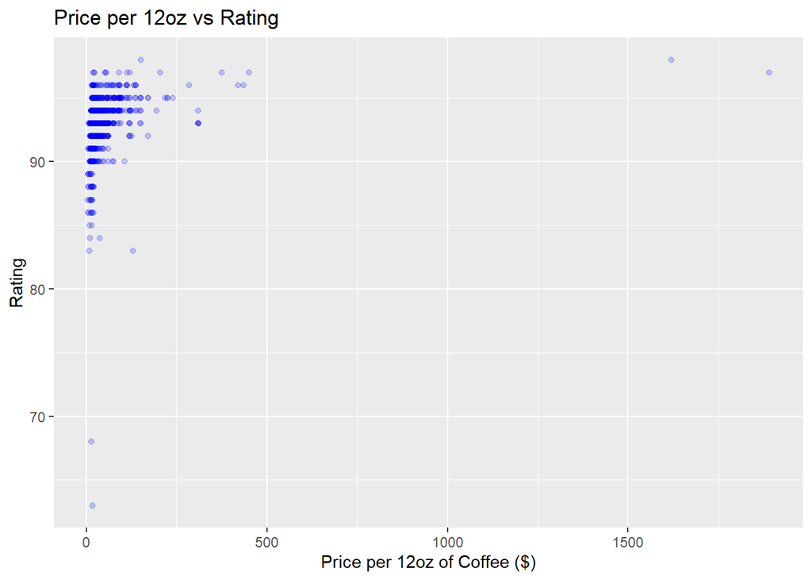

```r
#density scatterplot of price vs rating
ratingplot <- ggplot(coffee_data_standardized)+
               aes(x = price_per_12oz,
                   y = rating)+
                 geom_point(alpha = 0.2, colour = "blue")+
                 labs(title = "Price per 12oz vs Rating",
                      x = "Price per 12oz of Coffee ($)",
                      y = "Rating")
ratingplot
```

I created a scatterplot to have a visual representation of the coffee ratings and costs. There does appear to be an increase in quality with an increase in price, however given the very expensive outliers, it is difficult to determine how much. Within my budget, I wanted to see how many coffees were above the 89 benchmark and of those which coffees were highest rated. They are listed below with their ratings and prices per 12 ounces.

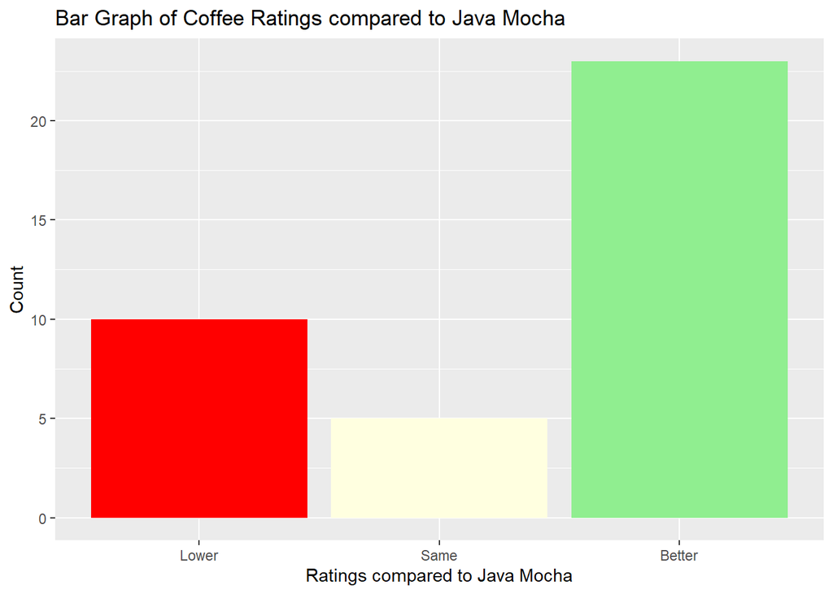

```r
rating_levels = c("Lower", "Same", "Better")
coffees_within_budget_unrated <- coffees_within_budget_unrated %>%
  mutate(
    rating_ranges = case_when(
      rating < 89 ~ "Lower",
      rating == 89 ~ "Same",
      rating > 89 ~ "Better"
    ),
    rating_ranges = factor(rating_ranges, rating_levels)
    # ) %>%
    #   mutate(
    #     rating_ranges = factor(rating_ranges, rating_levels),
    #     rating_ranges = fct_reorder(rating_ranges, rating_levels)
    #   )
  )

ggplot(coffees_within_budget_unrated,
       aes(x = rating_ranges))+
  geom_bar(fill = c("red", "lightyellow", "lightgreen"))+
  labs(x = "Ratings compared to Java Mocha",
       y = "Count",
       title = "Bar Graph of Coffee Ratings compared to Java Mocha")
```

To see how the coffees within my budget were rated in comparison to Java Mocha, I created a bar graph to visualize the distribution. I was surprised to find how many coffees there were with a better rating than Java Mocha.

```r
#Pull the coffees from this group with the highest ratings
final <- subset(coffees_within_budget, rating == max(rating))

final %>%
  summarize(roaster, name, rating, location, origin, roast, price_per_12oz, review_date) %>% gt_preview( top_n = 5, bottom_n = 5)
```

|  | roaster | name | rating | location | origin | roast | price_per_12oz | review_date |
| --- | --- | --- | --- | --- | --- | --- | --- | --- |
| 1 | Paradise Roasters | Organic Dulce de Guatemala | 93 | Ramsey, Minnesota | Huehuetenango growing region, Guatemala | Medium-Light | 11.95000 | August 2018 |
| 2 | Mystic Monk Coffee | Kenya AA Top Lot | 93 | Clark, Wyoming | South-central Kenya | Medium | 11.95000 | October 2018 |
| 3 | Columbia Street Roastery | 40-Hour Ethiopia Girma Eshetu | 93 | Champaign, Illinois | Bita Genet District, Keffa Zone, southwestern Ethiopia | Medium-Light | 9.00000 | July 2020 |
| 4 | Euphora Coffee | The World Espresso Blend | 93 | Taipei, Taiwan | Guatemala; Nicaragua; Ethiopia; Costa Rica; Indonesia; Brazil | Medium-Light | 7.50000 | May 2021 |
| 5 | Geisha Coffee Roaster | Elida Natural ASD (Panama) | 93 | Orlando, Florida | Boquete growing region, western Panama | Medium-Light | 11.05500 | May 2021 |
| 6 | Euphora | World 2.0 Espresso Blend | 93 | Taipei, Taiwan | Guatemala; Nicaragua; Ethiopia; Costa Rica; Indonesia; Brazil | Medium-Light | 7.50000 | October 2022 |
| 7 | El Gran Cafe | Proyecto Aurora | 93 | Antigua, Guatemala | Antigua growing region, Guatemala | Medium-Light | 10.00000 | November 2022 |
| 8 | El Gran Cafe | Finca El Potrero | 93 | Antigua, Guatemala | Antigua growing region, Guatemala | Medium-Light | 10.00000 | November 2022 |
| 9 | Kunshan Kokei co., LTD | H Coffee Espresso Blend 01 | 93 | Shanghai, China | Ethiopia; Colombia; Brazil | Medium | 10.31468 | September 2018 |

For my own curiosity, I increased my coffee budget and re-ran my analysis to see if I would be able find to find a significantly better coffee by spend 4 more dollars which would make my coffee budget $\$ 15.99$.

```r
coffees_within_higher_budget <- coffee_price_per_ounces %>%
  arrange(
    rating
  ) %>%
  filter(
    price_per_12oz <= (budget_per_bag + 4) &
      rating > 89
  )

coffees_within_higher_budget %>%
  tabyl(rating)
```

```
##  rating  n percent
##      90 42   0.168
##      91 45   0.180
##      92 77   0.308
##      93 60   0.240
##      94 23   0.092
##      95  1   0.004
##      96  2   0.008
```

```r
final2 <- subset(coffees_within_higher_budget, rating == max(rating))

final2 %>%
  summarize(roaster, name, rating, location, origin, roast, price_per_12oz, review_date) %>% gt()
```

| roaster | name | rating | location | origin | roast | price_per_12oz | review_date |
| --- | --- | --- | --- | --- | --- | --- | --- |
| Barrington Coffee Roasting | Twenty Five | 96 | Lee, Massachusetts | Ethiopia; Papua New Guinea; Guatemala | Medium-Light | 14.45 | October 2018 |
| Thanksgiving Coffee Company | Mocha Java | 96 | Fort Bragg, California | Sumatra; Ethiopia | Medium | 14.50 | May 2020 |

By adding just 4 dollars to my coffee budget, I am able to choose from 250 coffees that are rated above 90 and 2 of which that are rated at 96.

# 6. Final Summary

At the beginning of this project, I set out to determine if I could find a better rated coffee for the same price as I spend on a 12oz bag of Portland Coffee Roaster’s Goose Hollow beans. I was not sure if that would be possible as good coffee can be expensive. Based on this analysis, I can say that with the prices listed in the dataset, I can find a lot of better rated coffees for the same or lower price. I was surpised to see how many options there were because I tend to find whatever local coffee is the cheapest at the grocery store. One caveat to this conclusion is that the prices listed in this dataset may not have been updated since the review occurred for the coffee. Some of the reviews are as old as 2010 and due to global inflation, coffee prices have drastically changed in this time. Without an updated cost list, it is difficult to determine how well my analysis translates to the cost of coffee at your local grocery store this. That beginning said, with an updated cost list, this tool can be quickly updated to accommodate the new prices. At this point, the only thing left is to actually buy the coffees and determine if the additional few dollars are worth it. Cheers!

# 7. Project future paths

- Investigation into the very expensive coffees to determine if they are actually that price or is it an error
- Integrate other currencies